# Sf-Seq_Bi624

Devin Dinwiddie

October 06, 2017

### Data:

```
Devin   15_3C_mbnl  10_2G_both #data files I am working with
```

### Part 1 - SF-Seq read quality score distributions

#### 1)

```
 FastQC: FastQC/0.11.5-Java-1.8.0_131 #fastqc version
```

```bash
# fastqc sbatch script
fastqc 15_3C_mbnl_S11_L008_R1_001.fastq.gz 15_3C_mbnl_S11_L008_R2_001.fastq.gz 10_2G_both_S8_L008_R1_001.fastq.gz 10_2G_both_S8_L008_R2_001.fastq.gz -o fqcOut --noextract
```

#### 10_2G_R1

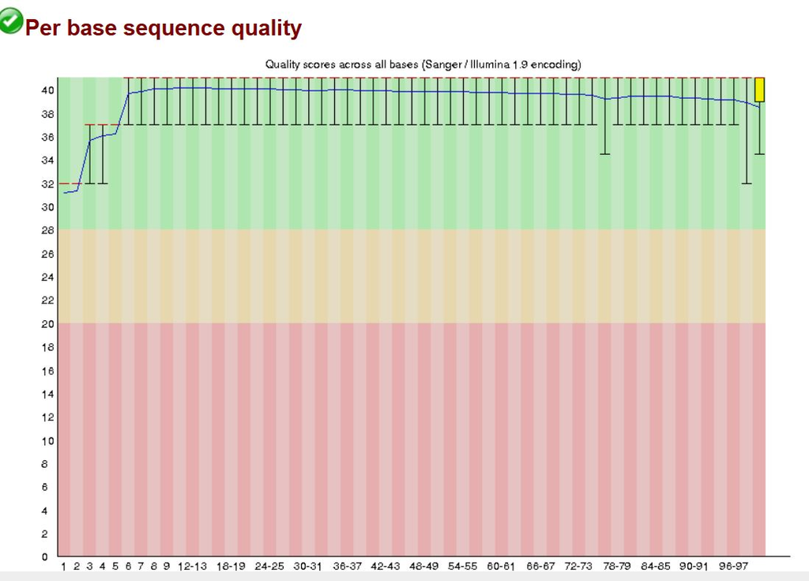

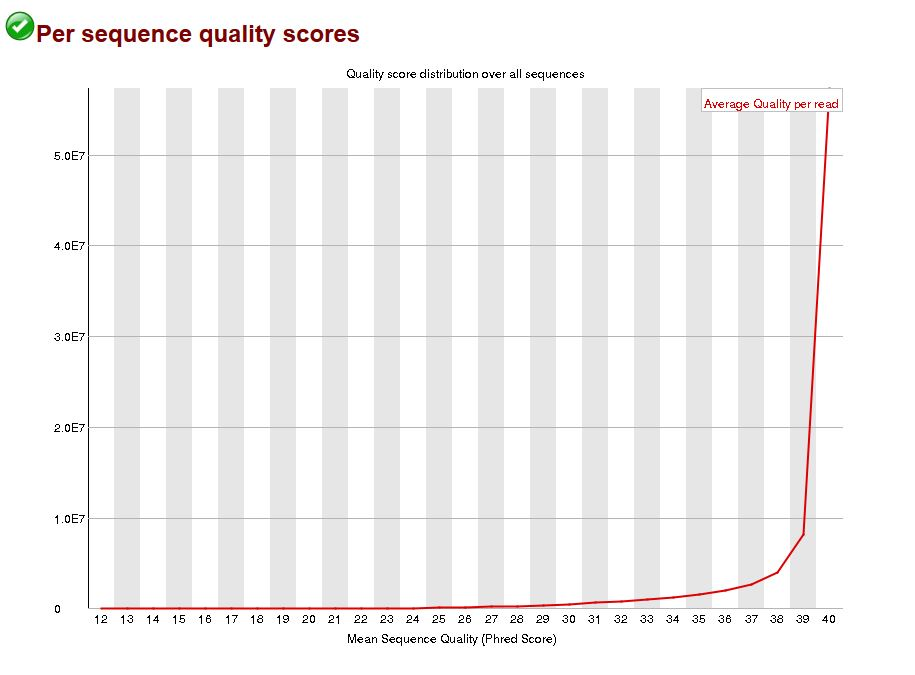

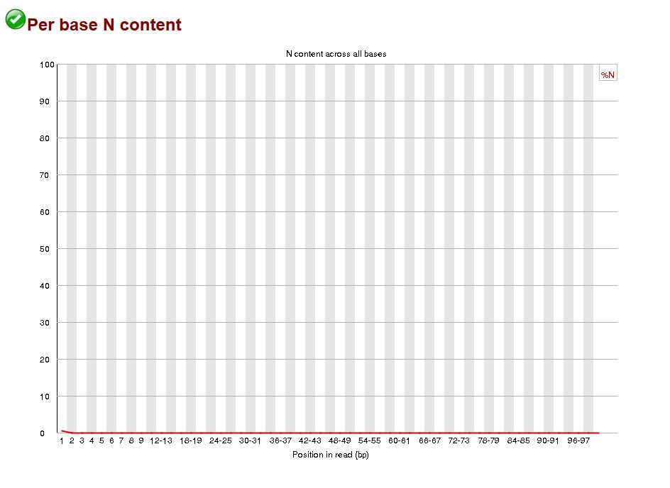

#### 10_2G_R2

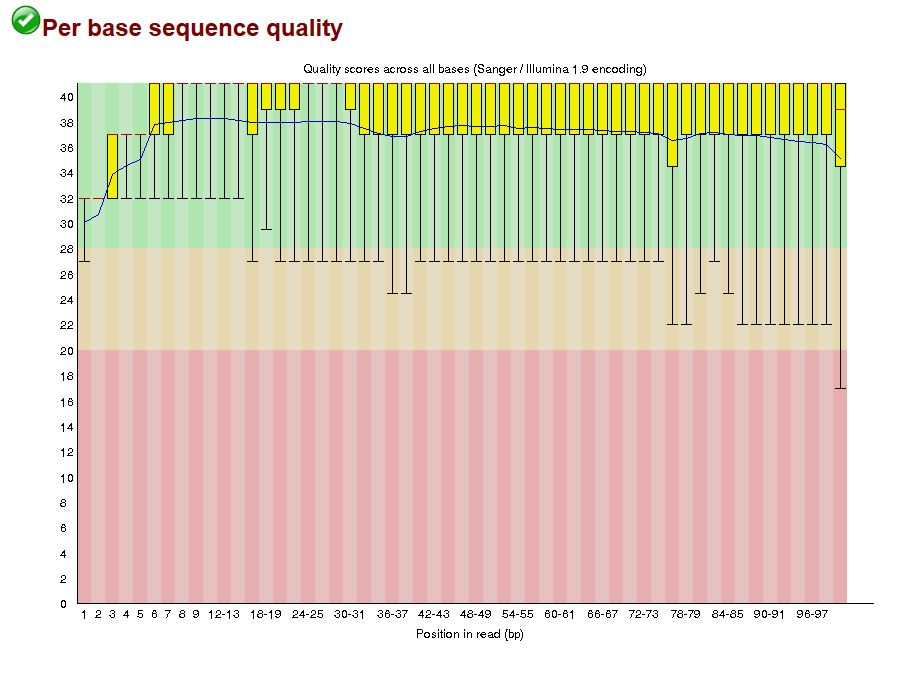

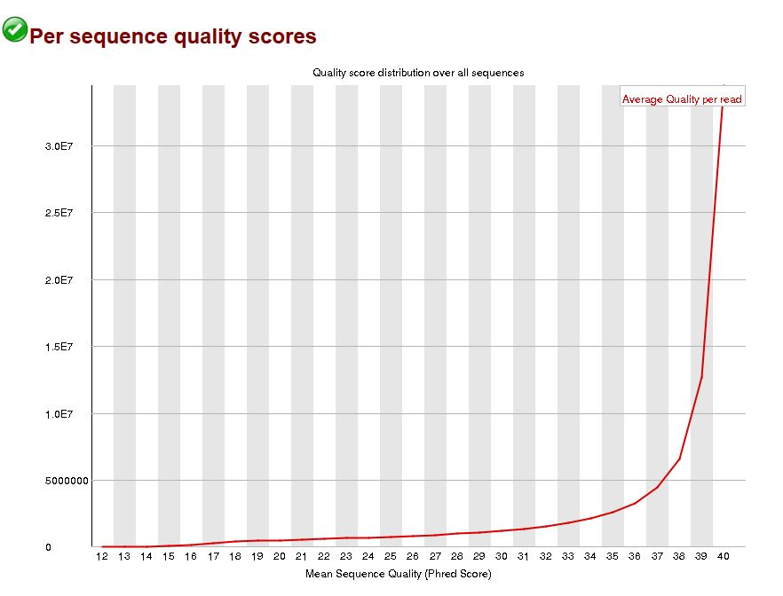

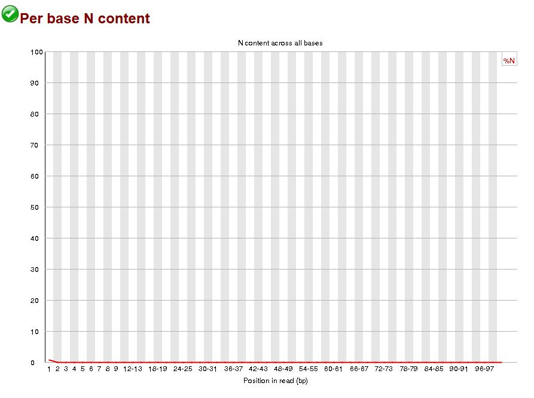

#### 15_3C_R1

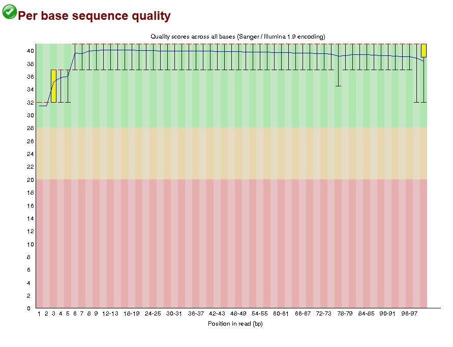

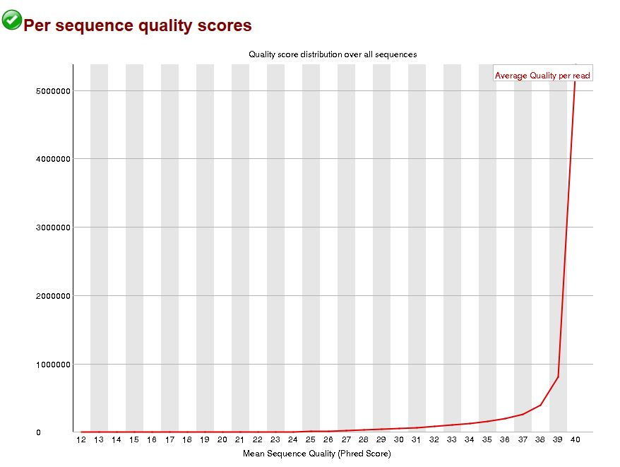

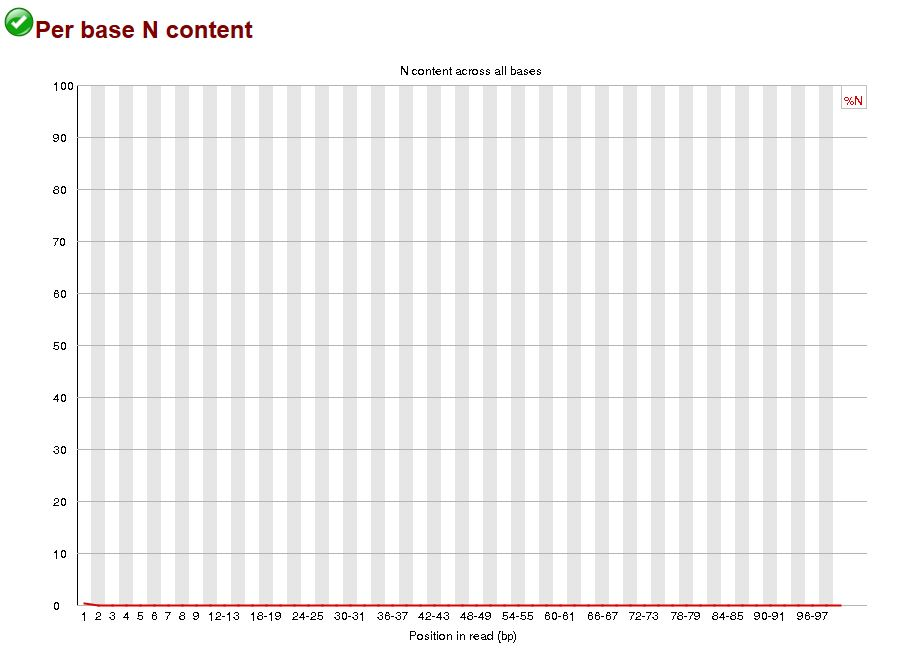

#### 15_3C_R2

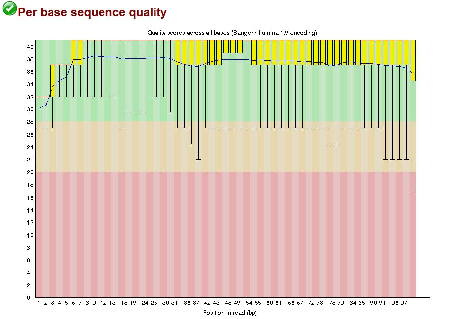

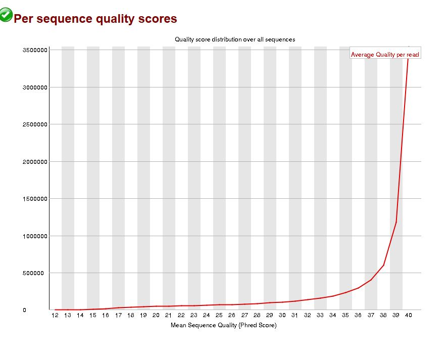

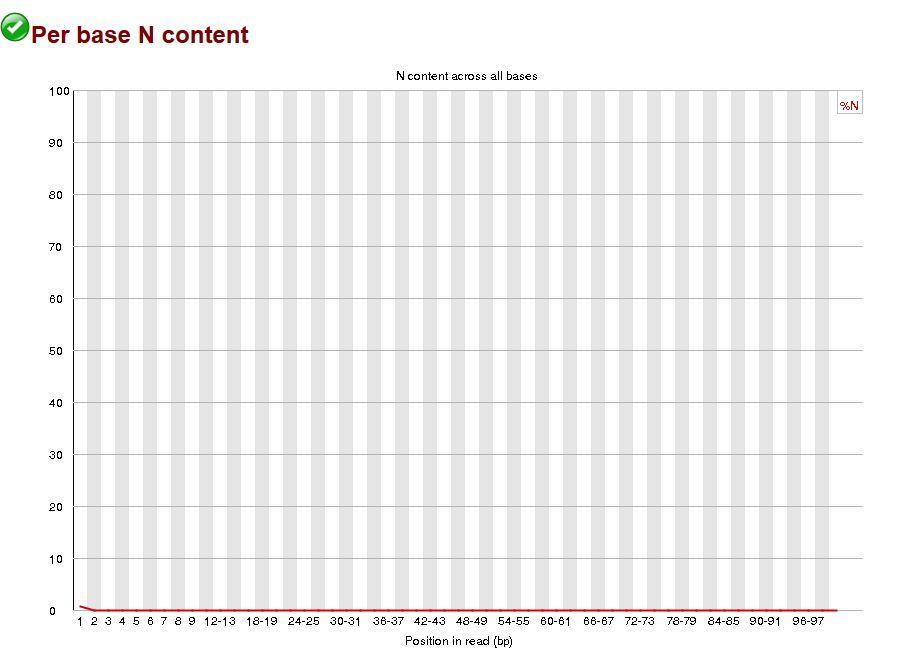

produce plots of the per-base N content, and comment on whether or not they are consistent with the quality score plots.

```
the per base N content for all four files is very low (0) and the per base qualitity scores are generally high (30+). N content would produce very low quality scores which I do not see so this seems consistent with expectations.
```

#### compare Fastqc with my quality score script.

#### 2)

```bash
# sbatch script for my quality script
module load python3/3.6.1
./qual_dist_zipped.py -f "10_2G_both_S8_L008_R1_001.fastq" -o1 "2GR1_Bpq.tsv" -o2 "2GR1_mlq.tsv" #2GR1
./qual_dist_zipped.py -f "10_2G_both_S8_L008_R2_001.fastq" -o1 "2GR2_Bpq.tsv" -o2 "2GR2_mlq.tsv" #2GR2
./qual_dist_zipped.py -f "15_3C_mbnl_S11_L008_R1_001.fastq" -o1 "3CR1_Bpq.tsv" -o2 "3CR1_mlq.tsv" #3CR1
./qual_dist_zipped.py -f "15_3C_mbnl_S11_L008_R2_001.fastq" -o1 "3CR2_Bpq.tsv" -o2 "3CR2_mlq.tsv" #3CR2
```

#### 10_2GR1

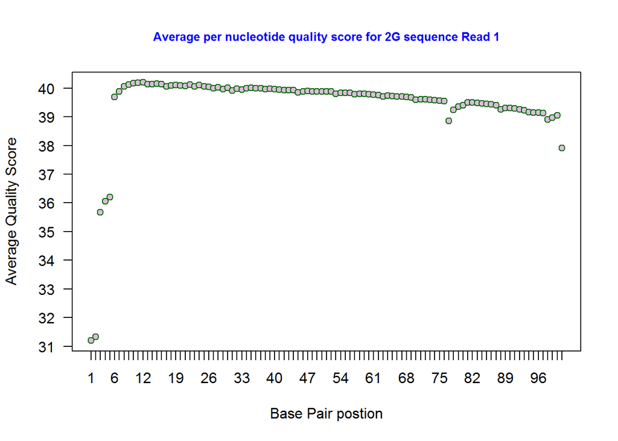

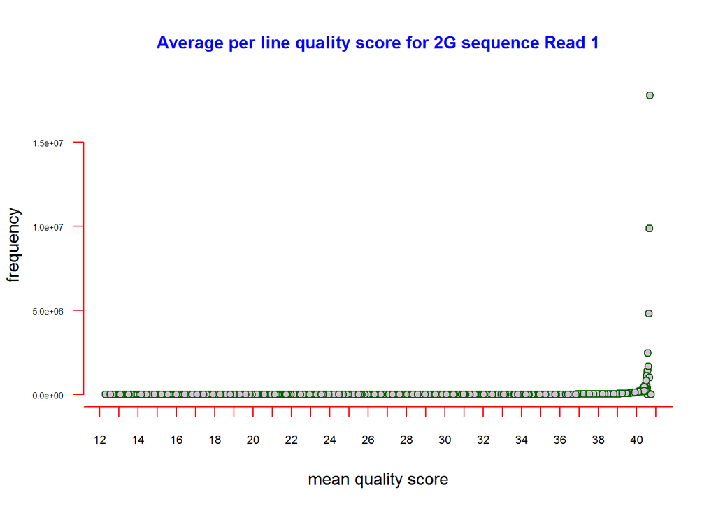

#### 10_2GR2

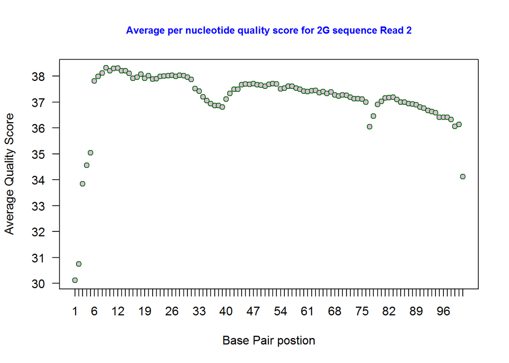

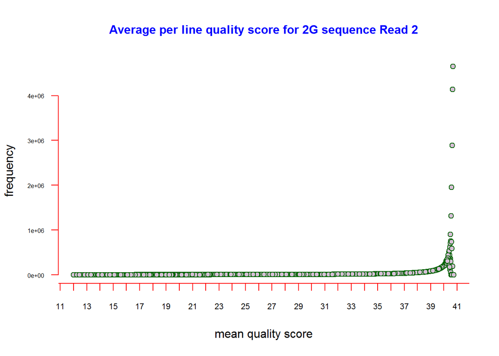

#### 15_3CR1

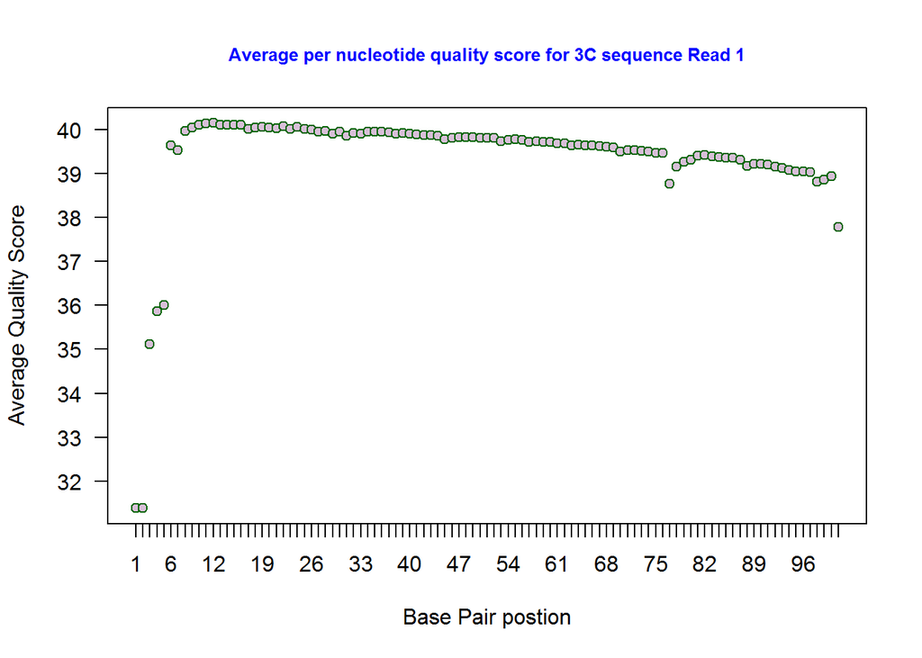

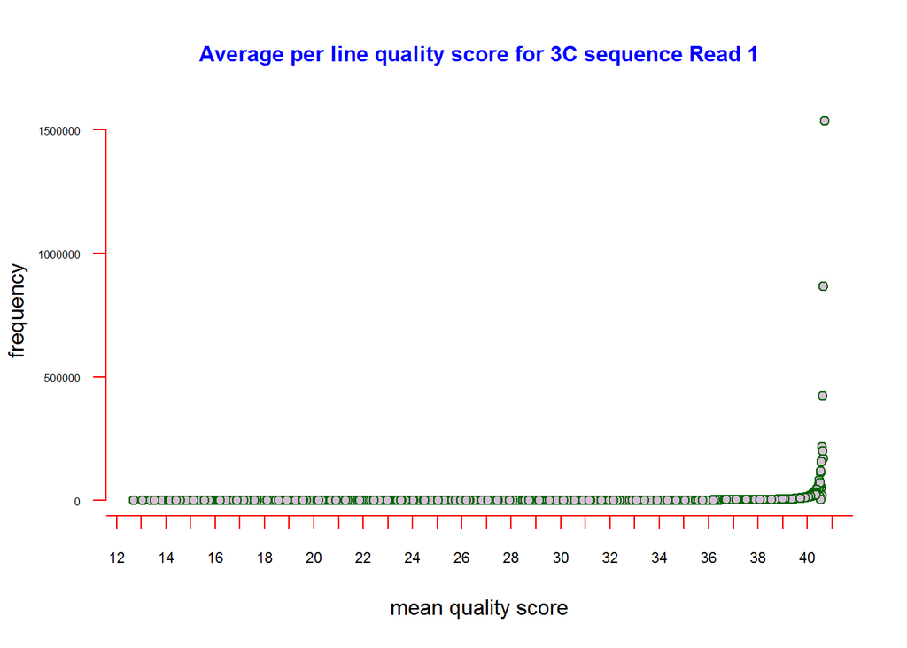

#### 15_3CR2

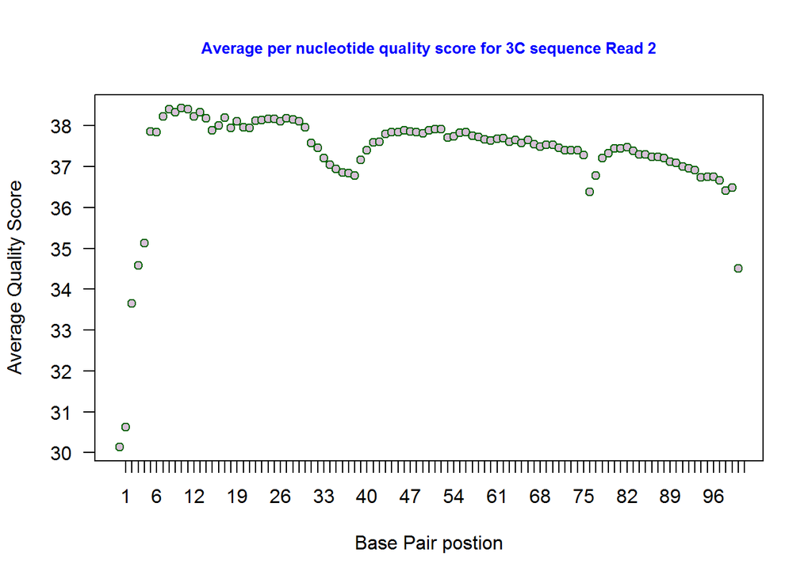

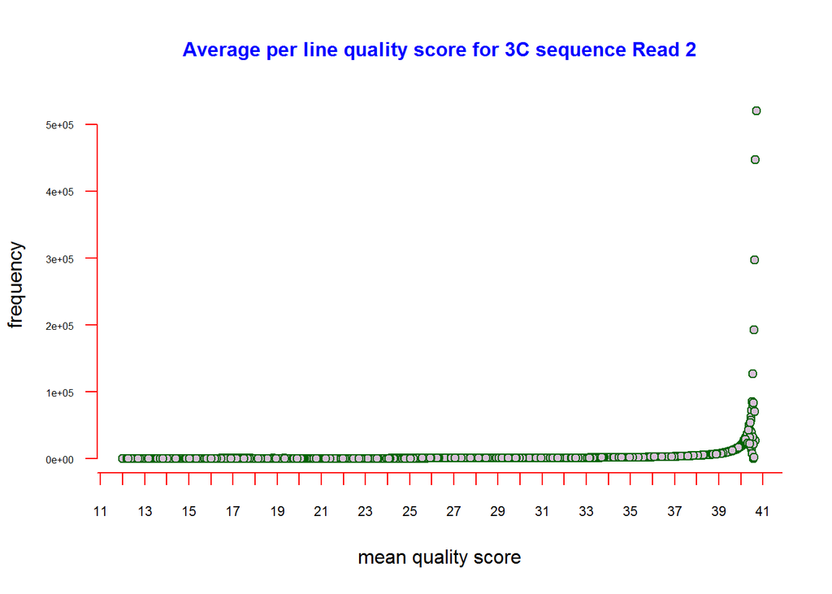

Describe how the `FastQC` quality score distribution plots compare to your own. If different, propose an explanation. Also, does the runtime differ? If so, why?

[output not shown]

### Part 2 - Adaptor trimming comparison

#### 3)

Look into the adaptor trimming options for `cutadapt`, `process_shortreads`, and `Trimmomatic` (all on Talapas), and briefly describe the differences

```
Trimmomatic
    Remove adapters (ILLUMINACLIP:TruSeq3-PE.fa:2:30:10)
    Remove leading low quality or N bases (below quality 3) (LEADING:3)
    Remove trailing low quality or N bases (below quality 3) (TRAILING:3)
    Scan the read with a 4-base wide sliding window, cutting when the average quality per base drops below 15 (SLIDINGWINDOW:4:15)
    Drop reads below the 36 bases long (MINLEN:36)
    written in java

cutadapt
    Cutadapt finds and removes adapter sequences, primers, poly-A tails
    and other types of unwanted sequence from your high-throughput sequencing reads.
    can adjust for anchored adapters.
    written in python

Process_shortreads
    trims reads below quality threshold makes them usefull for downstream analysis instead of discarding them. designed with Stacks for rad seq data. seperates  untrimmed paired end reads into seperate files. part of the stacks package.

These all do the same thing with a little different flavor but are esscentially the same.
```

```bash
# sbatch script for process short reads

ml easybuild  icc/2017.1.132-GCC-6.3.0-2.27  impi/2017.1.132  Stacks

process_shortreads  -1 /home/devind/Bi624/sf-seq/10_2G_both_S8_L008_R1_001.fastq.gz \
-2 /home/devind/Bi624/sf-seq/10_2G_both_S8_L008_R2_001.fastq.gz \
-i 'gzfastq' -o /home/devind/Bi624/sf-seq/2Gpro_out -c -q \
--adapter_1 AGATCGGAAGAGCACACGTCTGAACTCCAGTC \
--adapter_2 AGATCGGAAGAGCGTCGTGTAGGGAAAGAGTGT \
--adapter_mm 2

process_shortreads  -1 /home/devind/Bi624/sf-seq/15_3C_mbnl_S11_L008_R1_001.fastq.gz \
-2 /home/devind/Bi624/sf-seq/15_3C_mbnl_S11_L008_R2_001.fastq.gz \
-i 'gzfastq' -o /home/devind/Bi624/sf-seq/3Cpro_out -c -q \
--adapter_1 AGATCGGAAGAGCACACGTCTGAACTCCAGTC \
--adapter_2 AGATCGGAAGAGCGTCGTGTAGGGAAAGAGTGT \
--adapter_mm 2
```

What proportion of reads (both forward and reverse) was trimmed?

```
2G R1 & R2

162954138 total sequences;
  3522551 reads contained adapter sequence;
  0 ambiguous barcode drops;
  1326791 low quality read drops;
  1325639 trimmed reads;
  0 orphaned paired-end reads;
159430435 retained reads.

# 0.8% trimmed

3C R1 & R2

15612806 total sequences;
  716101 reads contained adapter sequence;
  0 ambiguous barcode drops;
  127153 low quality read drops;
  503805 trimmed reads;
  0 orphaned paired-end reads;
15273357 retained reads.

# 3.22% trimmed
```

#### 4)

Plot the trimmed read length distributions for both forward and reverse reads (on the same plot). If necessary, consult Assignment 5 (Block 1) from Bi 623 to refresh your memory.

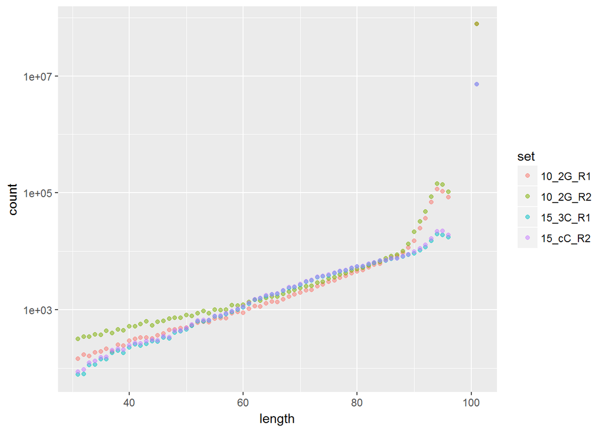

```bash
# determine the length of seq lines for each file output to new txt file
zcat 10_2G_both_S8_L008_R1_001.1.fq.gz | awk '{if(NR%4==2) print length($1)}' | sort -n | uniq -c > ../2GR1_cutLen.txt
zcat 10_2G_both_S8_L008_R2_001.2.fq.gz | awk '{if(NR%4==2) print length($1)}' | sort -n | uniq -c > ../2GR2_cutLen.txt
zcat 15_3C_mbnl_S11_L008_R1_001.1.fq.gz | awk '{if(NR%4==2) print length($1)}' | sort -n | uniq -c > ../3CR1_cutLen.txt
zcat 15_3C_mbnl_S11_L008_R2_001.2.fq.gz | awk '{if(NR%4==2) print length($1)}' | sort -n | uniq -c > ../3CR2_cutLen.txt
```

#### 5)

Briefly describe whether the adaptor trimming results are consistent with the insert size distributions for your libraries.

[output not shown]